# Regression on Cars Dataset

by Aleksander Partyga and Marian Nehrebecki

## Introduction

In this project we want to show different machine learning approaches in a regression problem. The main goal is to built a model which will predict a price of a car, based on the given set of features. The dataset was downloaded from [Kaggle](https://www.kaggle.com/lepchenkov/usedcarscatalog) and concerns set of more than 38 thousand cars that was scraped from the Belarusian listing website in December 2019.

The project can be divided into 2 main parts. In the first part we cover Exploratory Data Analysis and Data Preprocessing. We present graphically or numerically how every single variable is related to the price of a car and we draw preliminary conclusions about the effects of certain features. Additionally, we perform one-hot encoding and delete observations with missing data.

In the second part, after the data is prepared appropriately, we built three different types of models: Linear Regression, Regression Tree and XGBoost. We perform cross-validation, present some insights from the model learning process (for Regression Tree model) and build models with different set of parameters. At the end of each section we present how the model performed on the testing sample by measuring the size of the errors (with the Mean Absolute Error).

```python
import warnings
warnings.filterwarnings("ignore")
import time
```

```python
import seaborn as sns
import numpy as np
import pandas as pd
import matplotlib.pyplot as plt
%matplotlib inline
```

```python
cars = pd.read_csv('C:/Users/lenovo/Desktop/WNE/Machine Learning 2/Regression/cars.csv')
```

## EDA and Data Preprocessing

```python
cars.head()
```

|  | manufacturer_name | model_name | transmission | color | odometer_value | year_produced | engine_fuel | engine_has_gas | engine_type | engine_capacity | ... | feature_1 | feature_2 | feature_3 | feature_4 | feature_5 | feature_6 | feature_7 | feature_8 | feature_9 | duration_listed |
| --- | --- | --- | --- | --- | --- | --- | --- | --- | --- | --- | --- | --- | --- | --- | --- | --- | --- | --- | --- | --- | --- |
| 0 | Subaru | Outback | automatic | silver | 190000 | 2010 | gasoline | False | gasoline | 2.5 | ... | True | True | True | False | True | False | True | True | True | 16 |
| 1 | Subaru | Outback | automatic | blue | 290000 | 2002 | gasoline | False | gasoline | 3.0 | ... | True | False | False | True | True | False | False | False | True | 83 |
| 2 | Subaru | Forester | automatic | red | 402000 | 2001 | gasoline | False | gasoline | 2.5 | ... | True | False | False | False | False | False | False | True | True | 151 |
| 3 | Subaru | Impreza | mechanical | blue | 10000 | 1999 | gasoline | False | gasoline | 3.0 | ... | False | False | False | False | False | False | False | False | False | 86 |
| 4 | Subaru | Legacy | automatic | black | 280000 | 2001 | gasoline | False | gasoline | 2.5 | ... | True | False | True | True | False | False | False | False | True | 7 |

5 rows × 30 columns

```python
cars.info()
```

```
<class 'pandas.core.frame.DataFrame'>
RangeIndex: 38531 entries, 0 to 38530
Data columns (total 30 columns):
 #   Column             Non-Null Count  Dtype
---  ------             --------------  -----
 0   manufacturer_name  38531 non-null  object
 1   model_name         38531 non-null  object
 2   transmission       38531 non-null  object
 3   color              38531 non-null  object
 4   odometer_value     38531 non-null  int64
 5   year_produced      38531 non-null  int64
 6   engine_fuel        38531 non-null  object
 7   engine_has_gas     38531 non-null  bool
 8   engine_type        38531 non-null  object
 9   engine_capacity    38521 non-null  float64
```

[output cut: 22 more lines]

Since variables named as features_1 to features_9 are not described by the authors we decided to drop these and not use them in further analysis

```python
for i in range(10):
    cars.drop(f'feature_{i}', axis=1, inplace=True)
```

```python
cars.info()
```

```
<class 'pandas.core.frame.DataFrame'>
RangeIndex: 38531 entries, 0 to 38530
Data columns (total 20 columns):
 #   Column             Non-Null Count  Dtype
---  ------             --------------  -----
 0   manufacturer_name  38531 non-null  object
 1   model_name         38531 non-null  object
 2   transmission       38531 non-null  object
 3   color              38531 non-null  object
 4   odometer_value     38531 non-null  int64
 5   year_produced      38531 non-null  int64
 6   engine_fuel        38531 non-null  object
 7   engine_has_gas     38531 non-null  bool
 8   engine_type        38531 non-null  object
 9   engine_capacity    38521 non-null  float64
 10  body_type          38531 non-null  object
 11  has_warranty       38531 non-null  bool
 12  state              38531 non-null  object
 13  drivetrain         38531 non-null  object
 14  price_usd          38531 non-null  float64
 15  is_exchangeable    38531 non-null  bool
 16  location_region    38531 non-null  object
 17  number_of_photos   38531 non-null  int64
 18  up_counter         38531 non-null  int64
 19  duration_listed    38531 non-null  int64
dtypes: bool(3), float64(2), int64(5), object(10)
memory usage: 5.1+ MB
```

We end up with a list of **20 variables**, among which 7 are of numerical type (float64 and int64), 10 categorical (object) and 3 are boolean - True or False.

Let's explore the numerical ones first.

### Numerical variables

```python
cars.describe()
```

|  | odometer_value | year_produced | engine_capacity | price_usd | number_of_photos | up_counter | duration_listed |
| --- | --- | --- | --- | --- | --- | --- | --- |
| count | 38531.000000 | 38531.000000 | 38521.000000 | 38531.000000 | 38531.000000 | 38531.000000 | 38531.000000 |
| mean | 248864.638447 | 2002.943734 | 2.055161 | 6639.971021 | 9.649062 | 16.306091 | 80.577249 |
| std | 136072.376530 | 8.065731 | 0.671178 | 6428.152018 | 6.093217 | 43.286933 | 112.826569 |
| min | 0.000000 | 1942.000000 | 0.200000 | 1.000000 | 1.000000 | 1.000000 | 0.000000 |
| 25% | 158000.000000 | 1998.000000 | 1.600000 | 2100.000000 | 5.000000 | 2.000000 | 23.000000 |
| 50% | 250000.000000 | 2003.000000 | 2.000000 | 4800.000000 | 8.000000 | 5.000000 | 59.000000 |
| 75% | 325000.000000 | 2009.000000 | 2.300000 | 8990.000000 | 12.000000 | 16.000000 | 91.000000 |
| max | 1000000.000000 | 2019.000000 | 8.000000 | 50000.000000 | 86.000000 | 1861.000000 | 2232.000000 |

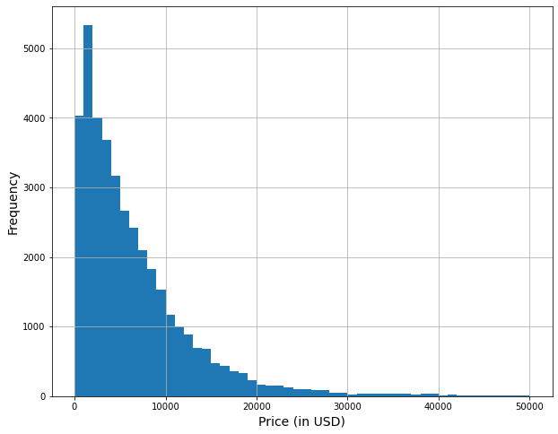

```python
plt.figure(figsize=(10, 8))
plt.xlabel('Price (in USD)', fontsize = 14)
plt.ylabel('Frequency', fontsize = 14)
cars['price_usd'].hist(bins=50)
```

```python
quantile = cars['price_usd'].quantile(q = 0.9)
print(f'Only 10 percent of the cars available at the website are more expensive than {quantile} USD')
```

```
Only 10 percent of the cars available at the website are more expensive than 14500.0 USD
```

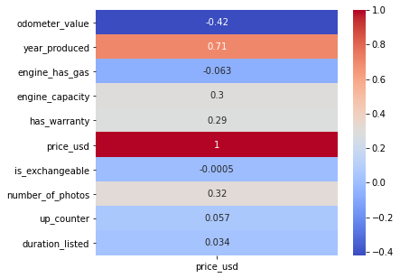

```python
plt.figure(figsize=(6,5))
corr_matrix = cars.corr()

sns.heatmap(corr_matrix[['price_usd']], cmap="coolwarm", annot=True)
plt.show()
```

Some of the variables seem to be highly correlated with the target variable, namely year in which the car was produced and odometer value (negative correlation). There are also a couple of variables that show mediocre correlation such as engine_capacity, number_of_photos and has_warranty.

While variable engine_has_gas has low correlation, it seems that gas affects the price negatively which is align with the intuiton (gas tends to be an option for lower class cars). This can be seen while exploring descriptive statistics:

```python
print('Price of the cars equipped with propaned tank and tubine \n')
print(cars['price_usd'][cars['engine_has_gas'] == True].describe())

print('\nPrice of the cars not equipped with propaned tank and tubine')
print(cars['price_usd'][cars['engine_has_gas'] == False].describe())
```

```
Price of the cars equipped with propaned tank and tubine

count     1347.000000
mean      4528.178664
std       4146.776327
min        180.000000
25%       1600.000000
50%       3300.000000
75%       6300.000000
max      37500.000000
Name: price_usd, dtype: float64

Price of the cars not equipped with propaned tank and tubine
count    37184.000000
mean      6716.471245
std       6482.913176
min          1.000000
25%       2199.000000
50%       4890.000000
75%       9000.000000
max      50000.000000
Name: price_usd, dtype: float64
```

It seems reasonable that the variables:

- readiness of the owner to exchange to car to other cars (is_exchangeable)
- how long ago was this offer posted (duration_listed)
- number of times the car has been upped (up_counter)

should not affect the price of the car. Let's drop them, which will help to avoid redundancy and overfitting problems. Let's now explore the correlations between the chosen numerical variables. Highly correlated (more than 0.7 / 0.8) variables are not desired in this case, as we want to avoid mulitcolinearlity problem.

```python
cars_numeric = cars[['odometer_value', 'engine_has_gas', 'has_warranty', 'engine_capacity', 'number_of_photos', 'year_produced']]
```

```python
numeric_corr = cars_numeric.corr()
numeric_corr.style.background_gradient(cmap = 'coolwarm')
```

|  | odometer_value | engine_has_gas | has_warranty | engine_capacity | number_of_photos | year_produced |
| --- | --- | --- | --- | --- | --- | --- |
| odometer_value | 1.000000 | 0.057786 | -0.189498 | 0.105704 | -0.143708 | -0.488679 |
| engine_has_gas | 0.057786 | 1.000000 | -0.020667 | 0.084579 | -0.032101 | -0.074686 |
| has_warranty | -0.189498 | -0.020667 | 1.000000 | -0.054583 | 0.084045 | 0.209231 |
| engine_capacity | 0.105704 | 0.084579 | -0.054583 | 1.000000 | 0.106691 | 0.005059 |
| number_of_photos | -0.143708 | -0.032101 | 0.084045 | 0.106691 | 1.000000 | 0.258180 |
| year_produced | -0.488679 | -0.074686 | 0.209231 | 0.005059 | 0.258180 | 1.000000 |

The highest (negative) correlation is -0.488 between year_produced and odomoter_value. Since this value is not overly high (in absolute terms) there is no need for dropping any of these two variables. Overall, we reduced set of numerical independent variables from 9 to 6. Let's now explore the categorical ones.

### Categorical variables

While exploring the categorical variables, I will focus on the groups in each category that are quite numerous (minimum number of observations will depend on how numerous the groups are). This is due to the fact that some of the variables have many categories and it would be hard to draw any conclusions from visualizing them all at once. Moreover groups with only a couple observations might be outliers, and a particular feature rather than an indicator of a clear pattern is an exception that should not be taken into account in case of extrapolating for a bigger sample.

```python
categorical_vars = cars.select_dtypes(include = ['object'])
categorical_vars.head()
```

|  | manufacturer_name | model_name | transmission | color | engine_fuel | engine_type | body_type | state | drivetrain | location_region |
| --- | --- | --- | --- | --- | --- | --- | --- | --- | --- | --- |
| 0 | Subaru | Outback | automatic | silver | gasoline | gasoline | universal | owned | all | Минская обл. |
| 1 | Subaru | Outback | automatic | blue | gasoline | gasoline | universal | owned | all | Минская обл. |
| 2 | Subaru | Forester | automatic | red | gasoline | gasoline | suv | owned | all | Минская обл. |
| 3 | Subaru | Impreza | mechanical | blue | gasoline | gasoline | sedan | owned | all | Минская обл. |
| 4 | Subaru | Legacy | automatic | black | gasoline | gasoline | universal | owned | all | Гомельская обл. |

Let's perform EDA on all categorical variables starting from the ones that appear on the left-hand side. As the list of manufacturers is long I will focus on the most popular brands, that appear at least 2000 times in our dataframe.

#### Manufacturer name

```python
len(cars['manufacturer_name'].unique())
```

```
55
```

```python
popular_manufacturers = cars.groupby('manufacturer_name').filter(lambda x: len(x) > 2000)
```

```python
# from matplotlib import rcParams
# rcParams['figure.figsize'] = [30, 10]
```

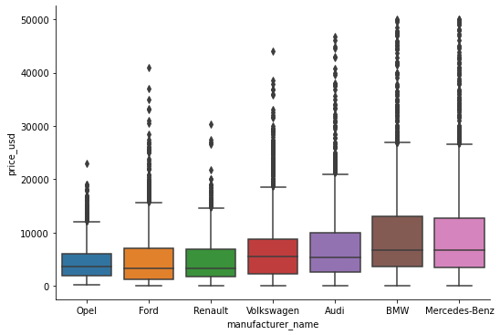

```python
sns.catplot(x="manufacturer_name", y = "price_usd", kind = "box", data = popular_manufacturers, aspect = 1.5)
```

It is clear that cars produced by premium manufacturers such as BMW or Mercedes-Benz **cost significantly more** (on average) in comparison to cars produced by Ford, Opel or Renault

#### Model name

```python
mercedes_benz = cars[cars["manufacturer_name"] == "Mercedes-Benz"]
popular_mercedes_benz = mercedes_benz.groupby('model_name').filter(lambda x: len(x) > 50)
```

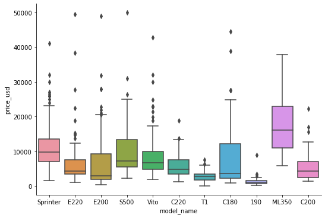

```python
sns.catplot(x="model_name", y = "price_usd", kind = "box", data = popular_mercedes_benz, aspect = 1.5)
```

Here, the relation is less obvious than in the manufacturers example. Yet, we can distguish **some models** produced by Mercedes-Benz (Sprinter or ML350) that **are more expensive than others**. Let's explore whether this variation in price can be seen for other manufacturer.

```python
ford = cars[cars["manufacturer_name"] == "Ford"]
popular_ford = ford.groupby('model_name').filter(lambda x: len(x) > 50)
```

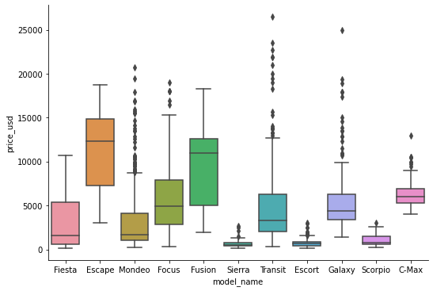

```python
sns.catplot(x="model_name", y = "price_usd", kind = "box", data = popular_ford, aspect = 1.5)
```

Ford models vary in price way more than Mercedes-Benz models. While some models of Ford (Sierra, Escort, Scorpio) rarely exceed the price of 2000 USD, others (i.e. Escape, Fusion) tend to much more expensive.

#### Transmission

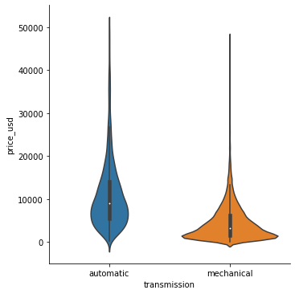

```python
sns.catplot(x="transmission", y = "price_usd", kind = "violin", data = cars)
```

Not suprisingly, cars with automatic transmission are more expensive (on average).

```python
color = cars.groupby('color').filter(lambda x: len(x) > 1000)
```

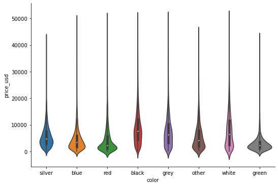

```python
sns.catplot(x="color", y = "price_usd", kind = "violin", data = color, aspect = 1.5)
```

It turns out that the cars painted with black or grey color are usually more expensive than those painted with green or red color. One should consider that **it is not the color that raises the price of a particular car**, rather people who spend more on their car tend to choose particular set of colors (less extravagant ones) more often.

#### Engine fuel

```python
print(cars['engine_fuel'].value_counts())
fuel = cars.groupby('engine_fuel').filter(lambda x: len(x) > 100)
```

```
gasoline         24065
diesel           12872
gas               1347
hybrid-petrol      235
electric            10
hybrid-diesel        2
Name: engine_fuel, dtype: int64
```

Lets omit electric and hybrid-diesel cars on our plot, since they occur very rarely

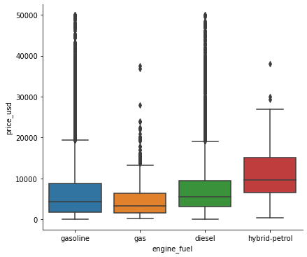

```python
sns.catplot(x="engine_fuel", y = "price_usd", kind = "box", data = fuel, aspect = 1.2)
```

Cars with hybrid-petrol engine fuel are on average more expensive than other types.

#### Engine type

```
gasoline    25647
diesel      12874
electric       10
Name: engine_type, dtype: int64
```

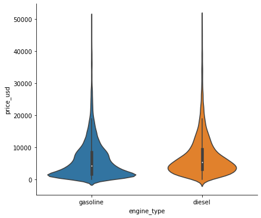

```python
print(cars['engine_type'].value_counts())
engine_type = cars.groupby('engine_type').filter(lambda x: len(x) > 100)
sns.catplot(x="engine_type", y = "price_usd", kind = "violin", data = engine_type, aspect = 1.2)
```

It seems that the **cheapest cars usually have gasoline engine type**. Medium-priced and expensive cars are similarly common for both type of engines.

#### Body type

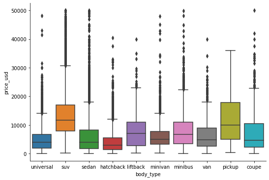

```python
body_type = cars.groupby('body_type').filter(lambda x: len(x) > 100)
sns.catplot(x="body_type", y = "price_usd", kind = "box", data = body_type, aspect = 1.5)
```

Out of all of the most common body types, only **SUV and pickup are considerably more expensive** than other body types at first glance.

#### State

```
owned        37723
new            438
emergency      370
Name: state, dtype: int64
```

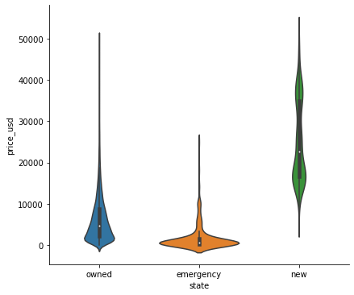

```python
print(cars['state'].value_counts())
sns.catplot(x="state", y = "price_usd", kind = "violin", data = cars, aspect = 1.2)
```

#### Drivetrain

```
front    27746
rear      5398
all       5387
Name: drivetrain, dtype: int64
```

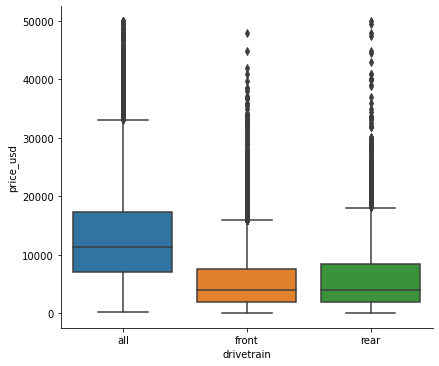

```python
print(cars['drivetrain'].value_counts())
sns.catplot(x="drivetrain", y = "price_usd", kind = "box", data = cars, aspect = 1.2)
```

Front-wheel drive is the most popular system, used in more than 70 % of listed cars. The price of cars with this system is very similar to price of the cars with rear-wheel drive system. On the other hand, we can expect **much higher price if the car has the four-wheel drive system**.

#### Location region

```
Минская обл.        24230
Гомельская обл.      3140
Витебская обл.       3007
Брестская обл.       2991
Могилевская обл.     2678
Гродненская обл.     2485
Name: location_region, dtype: int64
```

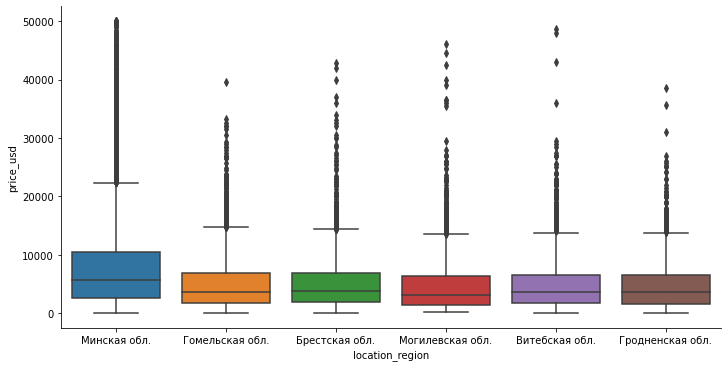

```python
print(cars['location_region'].value_counts())
sns.catplot(x="location_region", y = "price_usd", kind = "box", data = cars, aspect = 2)
```

The first region seen on the left-hand side is the **Minsk Region**. Since the capital city is the part of this region and and its inhabitants are **more affluent and more wiling to buy expensive cars**, the price of an average car listed in this region is more expensive in comparison to other regions.

All the variables were analyzed briefly and now we know what kind of effect we can expect from certain variables (or more precisely certain categories or values of the variables). Now, we are ready to proceed with modelling part of the project.

## Modelling

```python
from sklearn.model_selection import train_test_split
from sklearn.preprocessing import OneHotEncoder
```

```python
cars_new = pd.get_dummies(cars)
```

```python
cars_new.isnull().sum(axis = 0).sort_values(ascending = False)
```

```
engine_capacity                     10
odometer_value                       0
model_name_Nitro                     0
model_name_One                       0
model_name_Omega                     0
                                    ..
model_name_CLS400                    0
model_name_CLS350                    0
model_name_CLS320                    0
model_name_CLS250                    0
location_region_Могилевская обл.     0
Length: 1230, dtype: int64
```

Dropping rows where NA values occur.

```python
cars_new = cars_new[cars_new['engine_capacity'].notna()]
```

Storing the values of dependent variable seperately from the set of dependent variables .

```python
prices_new = cars_new['price_usd']
cars_new = cars_new.drop('price_usd', axis = 1)
```

```python
prices_new.describe()
```

```
count    38521.000000
mean      6637.160884
std       6425.198996
min          1.000000
25%       2100.000000
50%       4800.000000
75%       8950.000000
max      50000.000000
Name: price_usd, dtype: float64
```

Splitting the dataset into training and testing samples.

```python
cars_train, cars_test, prices_train, prices_test = train_test_split(cars_new, prices_new, train_size = 0.8, random_state = 13)
```

### Linear Regression

```python
from sklearn.linear_model import LinearRegression
```

```python
lin_reg = LinearRegression()
lin_reg.fit(cars_train, prices_train)
```

```
LinearRegression()
```

```python
lr_prices_predictions = lin_reg.predict(cars_test)
```

#### Let's explore how good the model is

```python
prices_test.describe()
```

```
count     7705.000000
mean      6614.812039
std       6372.033063
min          1.000000
25%       2050.000000
50%       4700.000000
75%       8999.000000
max      49416.400000
Name: price_usd, dtype: float64
```

```python
print(f'In {round(len(lr_prices_predictions[lr_prices_predictions < 0]) / len(lr_prices_predictions)*100, 2)}% of cases the linear model predicted negative price of a car.')
```

```
In 6.77% of cases the linear model predicted negative price of a car.
```

Let's visualize the residuals, compute the mean absolute error (MAE) and mean absolute percentage error (MAPE)

```python
from sklearn.metrics import mean_absolute_error, mean_absolute_percentage_error
from sklearn.model_selection import cross_val_score, ShuffleSplit
```

```python
# Computing MAE and MAPE
mae_lin = round(mean_absolute_error(prices_test, lr_prices_predictions), 0)
mape_lin = round(mean_absolute_percentage_error(prices_test, lr_prices_predictions), 3)
```

#### How big are the errors?

```python
print(f'The mean absolute error of linear regression model is \033[1m{mae_lin} USD\033[0m. The value of mean absolute percentage error for this model is: \033[1m{mape_lin*100}%\033[0m.\n')
```

```
The mean absolute error of linear regression model is 1663.0 USD. The value of mean absolute percentage error for this model is: 185.0%.
```

```python
lr_prices_predictions[200:210]
```

```
array([10571.53129355, -3430.65522505,  4657.43548393, 12606.55676682,
       22943.77839886,  9230.23411911,  3290.08339053,  1257.00515548,
          49.18215478,  3423.47638873])
```

```python
prices_test[200:210]
```

```
26027     9000.0
30263      250.0
11523     5700.0
8350       550.0
22215    27999.0
24325     8899.0
25513     4200.0
16518     1250.0
8086      1400.0
9411      4000.0
Name: price_usd, dtype: float64
```

The MAPE error is very high, **since the model handles small prices very poorly** (due to assumed linear relationship between the variables). Let's see how it performs when we consider only cars that cost over 2 thousand dollars.

```python
# Filtering for observations in the testing sample where price of a car is greater than 2000 USD
prices_over_2k = prices_test[prices_test > 2000]
```

```python
# Filtering for observations in the predictions dataset where corresponding price of a car in a testing sample is greater than 2000 USD
predictions_when_prices_over_2k = lr_prices_predictions[prices_test > 2000]
```

```python
mae_lin_2k = round(mean_absolute_error(prices_over_2k, predictions_when_prices_over_2k), 0)
mape_lin_2k = round(mean_absolute_percentage_error(prices_over_2k, predictions_when_prices_over_2k), 3)
```

```python
print(f'When only cars that cost over 2 thousand USD are considered, the mean absolute error of linear regression model is \033[1m{mae_lin_2k} USD\033[0m. The value of mean absolute percentage error for this model is: \033[1m{mape_lin_2k*100}%\033[0m.\n')
```

```
When only cars that cost over 2 thousand USD are considered, the mean absolute error of linear regression model is 1788.0 USD. The value of mean absolute percentage error for this model is: 25.3%.
```

Now the results are much better in terms of MAPE but worse in terms of MAE! This resulst indicate that using Mean Absolute Error is a better performance metric when the whole spectrum of cars prices is concerned. Therefore, to evaluate performance of models we will stick with MAE for the rest of this project. Lets try some more sophisticated modelling methods and see whether they will further improve the results.

#### Cross - validation results

**We perform a 5-fold cross-validation to be sure that obtained results are stable**. We use a function ShuffleSplit() that splits the data in a defined proportions (in case of our model it will be 4:1) and sample observations randomly. This way we can ensure that observations much different from each other (especially in terms of prices) will fall into each split. We do that in case the data was ordered in any way originally.

```python
lin_reg_cval = cross_val_score(lin_reg, cars_new, prices_new, cv = ShuffleSplit(n_splits = 5, random_state = 13, train_size = 0.8), scoring = 'neg_mean_absolute_error')
```

```python
lin_reg_cval
```

```
array([-1663.3537874 , -1671.80707665, -1665.3232513 , -1634.82210999,
       -1672.51186821])
```

```python
mean_mae_lin_reg = lin_reg_cval.mean()
```

```python
print(f"After performing cross-validation, the Mean Absolute Error (MAE) of the model is: \033[1m{round(abs(mean_mae_lin_reg), 2)}\033[0m, which is very similar to results obtained previously.")
```

```
After performing cross-validation, the Mean Absolute Error (MAE) of the model is: 1661.56, which is very similar to results obtained previously.
```

### Regression Tree

Function below were found in a Kaggle [Notebook](https://www.kaggle.com/samratp/boston-housing-prices-evaluation-validation/notebook) written by Samrat Pandiri. They were adjusted for the purpose of this project.

```python
from sklearn.tree import DecisionTreeRegressor
from sklearn.model_selection import GridSearchCV, learning_curve, validation_curve, KFold
%pylab inline
```

#### Learning Curve

```python
def ModelLearning(X, y):
    """ Calculates the performance of several models with varying sizes of training data.
        The learning and testing scores for each model are then plotted. """

    # Create 5-fold cross-validation sets for training and testing
    cv = ShuffleSplit(n_splits = 5, test_size = 0.2, random_state = 13)
    cv.get_n_splits(X)

    # Generate the training set sizes increasing by 1/6 of the whole training sample (~50k of observations)
    train_sizes = np.rint(np.linspace(1, X.shape[0]*0.8 - 1, 7)).astype(int)

    # Create the figure window
    fig = plt.figure(figsize=(12,6))

    # Create three different models based on max_depth
    for k, depth in enumerate([5,10,15,20]):

        # measure time at the start of the loop
        start_time = time.time()

        # Create a Decision tree regressor at max_depth = depth
        regressor = DecisionTreeRegressor(max_depth = depth, min_samples_leaf = 10)

        # Calculate the training and testing scores
        sizes, train_scores, test_scores = learning_curve(regressor, X, y, \
            cv = cv, train_sizes = train_sizes, scoring = 'neg_mean_absolute_error')

        # Find the mean and standard deviation for smoothing
        train_mean = np.mean(train_scores, axis = 1)
        test_mean = np.mean(test_scores, axis = 1)

        # Subplot the learning curve
        ax = fig.add_subplot(2, 2, k+1)
        ax.plot(sizes, train_mean, 'o-', color = 'r', label = 'Training Sample')
        ax.plot(sizes, test_mean, 'o-', color = 'g', label = 'Testing Sample')

        # Labels
        ax.set_title('max_depth = %s'%(depth))
        ax.set_xlabel('Number of Training Points')
        ax.set_ylabel('Negative MAE (in USD)')
        ax.set_xlim([0, X.shape[0]*0.8])
        ax.set_ylim([-2000, -1000])
        ax.grid()

        # How much time single loop lasts
        elapsed_time = round((time.time() - start_time), 2)

        print(f'Learning rate of tree with depth {depth} was computed in {elapsed_time} seconds')

    # Visual aesthetics
    ax.legend(loc='best')
    fig.suptitle('Decision Tree Regressor Learning Performances', fontsize = 16, y = 1.03)
    fig.tight_layout()
    fig.show()
```

```
Learning rate of tree with depth 5 was computed in 90.93 seconds
Learning rate of tree with depth 10 was computed in 98.26 seconds
Learning rate of tree with depth 15 was computed in 100.88 seconds
Learning rate of tree with depth 20 was computed in 106.95 seconds
```

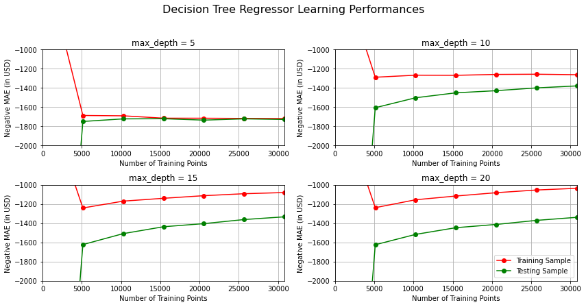

```python
ModelLearning(cars_new, prices_new)
```

On the graphics above we see can learning curves of training and testing datasets corresponding to *Decision Tree Regression* model with different max_depth (maxium depth of a tree) parameter. 5-fold cross-validation was performed to get an accurate measure of the Mean Absolute Error across different samples of training and test data.

- The model with max_depth = 5 is underfitted. As the number of training point grows it does not show any improvement in performance for both training and testing sample.
- The model with max_depth = 10 is much better. It's performance increases with every iteration (5 thousand observations), for the testing sample, but for the training sample remains stagnant.
- Models with max_depth = 15 and max_depth = 20 perform similarly well. One slight difference is the gap between the training sample and testing sample, as for the deeper regression tree the gap seems to be a little bit wider.

As max_depth is being optimized the **min_samples_leaf is set arbitrally to 10** to dissallow forming leaves with just a few observations and make the model more general in its usage (hence, preventing the overfitting).

#### Validation Curve

```python
def ModelComplexity(X, y):
    """ Calculates the performance of the model as model complexity increases.
        The learning and testing errors rates are then plotted. """

    # Create 5 cross-validation sets for training and testing
    cv = ShuffleSplit(n_splits = 5, test_size = 0.2, random_state = 13)

    # Vary the max_depth parameter from 5 to 20 by a step of 2
    max_depth = np.arange(5, 20, 2)

    # Calculate the training and testing scores
    train_scores, test_scores = validation_curve(DecisionTreeRegressor(min_samples_leaf = 10), X, y, \
        param_name = "max_depth", param_range = max_depth, cv = cv, scoring = 'neg_mean_absolute_error')

    # Find the mean
    train_mean = np.mean(train_scores, axis=1)
    test_mean = np.mean(test_scores, axis=1)

    # Plot the validation curve
    plt.figure(figsize=(7, 5))
    plt.title('Decision Tree Regressor Complexity Performance')
    plt.plot(max_depth, train_mean, 'o-', color = 'r', label = 'Training Score')
    plt.plot(max_depth, test_mean, 'o-', color = 'g', label = 'Validation Score')

    # Visual aesthetics
    plt.legend(loc = 'best')
    plt.xlabel('Maximum Depth')
    plt.ylabel('Negative Mean Absolute Error')
    plt.xticks(np.arange(3, 21, 2))
    plt.ylim([-2000, -1000])
    plt.grid()
    plt.show()
```

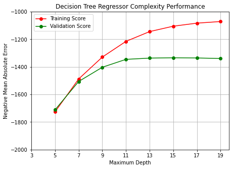

```
Wall time: 2min 52s
```

```python
%%time
ModelComplexity(cars_train, prices_train)
```

The *validationCurve()* function has proven on the graphic above, that *Decision Tree Regression* model yields the best results on the validation dataset when the max_depth parameter is set to 15 (while the min_samples_leaf was arbitraily set to 10).

The results of this function have formally confirmed what was visible on the previous graphic. After performing 5-fold cross-validation we can conclude that the best results can be achieved with the maximum depth of the tree equal to 15.

```python
reg_tree = DecisionTreeRegressor(max_depth = 15, random_state = 13, min_samples_leaf = 10)
```

```python
c_val = cross_val_score(reg_tree, cars_new, prices_new, cv = ShuffleSplit(n_splits = 5, random_state = 13), scoring = 'neg_mean_absolute_error')
print(c_val)
```

[output not shown]

### XGBoost

```python
import xgboost as xgb
from sklearn.model_selection import StratifiedKFold, RandomizedSearchCV, GridSearchCV
```

#### XGBoost model with 200 trees

Our first XGBoost model will be built with the use of default parameters, changing only n_estimators to 200 and learning_rate to 0.1.

```python
clf_xgb_200 = xgb.XGBRegressor(n_estimators = 200, learning_rate = 0.1, objective = 'reg:squarederror', seed = 13)
clf_xgb_200
```

```
XGBRegressor(base_score=None, booster=None, colsample_bylevel=None,
             colsample_bynode=None, colsample_bytree=None,
             enable_categorical=False, gamma=None, gpu_id=None,
             importance_type=None, interaction_constraints=None,
             learning_rate=0.1, max_delta_step=None, max_depth=None,
             min_child_weight=None, missing=nan, monotone_constraints=None,
             n_estimators=200, n_jobs=None, num_parallel_tree=None,
             predictor=None, random_state=None, reg_alpha=None, reg_lambda=None,
             scale_pos_weight=None, seed=13, subsample=None, tree_method=None,
             validate_parameters=None, verbosity=None)
```

```python
clf_xgb_200.fit(cars_train,
           prices_train,
           verbose = True,
           early_stopping_rounds = 5, # stop building trees if 5 following trees do not improve the performance
           eval_metric = 'mae',
           eval_set = [(cars_test, prices_test)])
```

```
XGBRegressor(base_score=0.5, booster='gbtree', colsample_bylevel=1,
             colsample_bynode=1, colsample_bytree=1, enable_categorical=False,
             gamma=0, gpu_id=-1, importance_type=None,
             interaction_constraints='', learning_rate=0.1, max_delta_step=0,
             max_depth=6, min_child_weight=1, missing=nan,
             monotone_constraints='()', n_estimators=200, n_jobs=8,
             num_parallel_tree=1, predictor='auto', random_state=13,
             reg_alpha=0, reg_lambda=1, scale_pos_weight=1, seed=13,
             subsample=1, tree_method='exact', validate_parameters=1,
             verbosity=None)
```

#### XGBoost model with 1000 trees

```python
clf_xgb_1000 = xgb.XGBRegressor(n_estimators = 1000, learning_rate = 0.1, objective = 'reg:squarederror', seed = 13)
clf_xgb_1000
```

```
XGBRegressor(base_score=None, booster=None, colsample_bylevel=None,
             colsample_bynode=None, colsample_bytree=None,
             enable_categorical=False, gamma=None, gpu_id=None,
             importance_type=None, interaction_constraints=None,
             learning_rate=0.1, max_delta_step=None, max_depth=None,
             min_child_weight=None, missing=nan, monotone_constraints=None,
             n_estimators=1000, n_jobs=None, num_parallel_tree=None,
             predictor=None, random_state=None, reg_alpha=None, reg_lambda=None,
             scale_pos_weight=None, seed=13, subsample=None, tree_method=None,
             validate_parameters=None, verbosity=None)
```

```python
clf_xgb_1000.fit(cars_train,
           prices_train,
           verbose = True,
           early_stopping_rounds = 5, # stop building trees if 5 following trees do not improve the performance
           eval_metric = 'mae',
           eval_set = [(cars_test, prices_test)])
```

```
XGBRegressor(base_score=0.5, booster='gbtree', colsample_bylevel=1,
             colsample_bynode=1, colsample_bytree=1, enable_categorical=False,
             gamma=0, gpu_id=-1, importance_type=None,
             interaction_constraints='', learning_rate=0.1, max_delta_step=0,
             max_depth=6, min_child_weight=1, missing=nan,
             monotone_constraints='()', n_estimators=1000, n_jobs=8,
             num_parallel_tree=1, predictor='auto', random_state=13,
             reg_alpha=0, reg_lambda=1, scale_pos_weight=1, seed=13,
             subsample=1, tree_method='exact', validate_parameters=1,
             verbosity=None)
```

#### XGB tuned model

Let's name a few most important parameters that are going to be tuned (whole list of parameters along with their definitions can be found in the offical [documentation](https://xgboost.readthedocs.io/en/stable/python/python_api.html)):

- **max_depth**: maximum tree depth (opitmization process shown in the Regression Tree model before)
- **learning_rate** (eta - boosting learning rate)
- **gamma**: minimum loss reduction required to make a further partition on a leaf node of the tree. Increase in this parameter encourages pruning.
- **colsample_bytree**: subsample ratio of columns when constructing each tree

```python
params_1 = {
    'max_depth': [5, 8, 11, 14],
    'gamma': [0.5, 1, 1.5]
}
```

This time we perform only a **3-fold cross-validation**, as tuning the XGBoost parameters is very computationally expensive. The parameters that will be tuned are defined in a dictionary called *params_1*. The combination of parameters **will be drawn 5 times in a random fashion** and then the fitting and measuring performance (MAE) of the model will be repeated 3 times in a cross-validation process.

In the first round parameters: *max_depth* and *gamma* will be tuned.

In the second round parameters: *learning_rate* and *colsample_bytree* will be tuned.

Lastly, the performance of the model with tuned parameters is going to be assessed.

```python
%%time

ss = ShuffleSplit(n_splits = 3, test_size = 0.2, random_state = 13)

random_search = RandomizedSearchCV(clf_xgb_200, param_distributions = params_1, verbose = 3, n_iter = 5, scoring = 'neg_mean_absolute_error',
                                  cv = ss.split(cars_new, prices_new), n_jobs= 4, random_state = 13)

random_search.fit(cars_new,
                  prices_new)
```

```
Fitting 3 folds for each of 5 candidates, totalling 15 fits
Wall time: 33min 3s
```

```
RandomizedSearchCV(cv=<generator object BaseShuffleSplit.split at 0x000001CDB7B642E0>,
                   estimator=XGBRegressor(base_score=0.5, booster='gbtree',
                                          colsample_bylevel=1,
                                          colsample_bynode=1,
                                          colsample_bytree=1,
                                          enable_categorical=False, gamma=0,
                                          gpu_id=-1, importance_type=None,
                                          interaction_constraints='',
                                          learning_rate=0.1, max_delta_step=0,
                                          max_depth=6, min_child_weight=...
                                          monotone_constraints='()',
                                          n_estimators=200, n_jobs=8,
                                          num_parallel_tree=1, predictor='auto',
                                          random_state=13, reg_alpha=0,
                                          reg_lambda=1, scale_pos_weight=1,
                                          seed=13, subsample=1,
                                          tree_method='exact',
                                          validate_parameters=1,
                                          verbosity=None),
                   n_iter=5, n_jobs=4,
                   param_distributions={'gamma': [0.5, 1, 1.5],
                                        'max_depth': [5, 8, 11, 14]},
                   random_state=13, scoring='neg_mean_absolute_error',
                   verbose=3)
```

```python
print(random_search.best_params_)
```

```
{'max_depth': 14, 'gamma': 1}
```

```python
print(random_search.best_score_)
```

```
-987.7694503170164
```

A XGBoost model with tuned parameters: max_depth = 14 and gamma = 1 achieved very promising result: Mean Absolute Eror equal to around **988** on the testing data. Let's optimize the final two parameters

- **learning_rate**
- **colsample_bytree**

```python
params_2 = {
    'colsample_bytree':[i/10.0 for i in range(7,10)],
    'learning_rate': [0.05, 0.1, 0.2, 0.3]
}
```

```python
%%time

clf_xgb_200_opt = xgb.XGBRegressor(n_estimators = 200, learning_rate = 0.1, max_depth = 14, gamma = 1, objective = 'reg:squarederror', seed = 13)

random_search = RandomizedSearchCV(clf_xgb_200_opt, param_distributions = params_2, n_iter = 5, scoring = 'neg_mean_absolute_error',
                                  cv = ss.split(cars_new, prices_new), n_jobs= 4, random_state = 13)

random_search.fit(cars_new,
                  prices_new)
```

```
Wall time: 38min 49s
```

```
RandomizedSearchCV(cv=<generator object BaseShuffleSplit.split at 0x000001CDB7C76430>,
                   estimator=XGBRegressor(base_score=None, booster=None,
                                          colsample_bylevel=None,
                                          colsample_bynode=None,
                                          colsample_bytree=None,
                                          enable_categorical=False, gamma=1,
                                          gpu_id=None, importance_type=None,
                                          interaction_constraints=None,
                                          learning_rate=0.1,
                                          max_delta_step=None, max_depth=14,
                                          min...
                                          n_estimators=200, n_jobs=None,
                                          num_parallel_tree=None,
                                          predictor=None, random_state=None,
                                          reg_alpha=None, reg_lambda=None,
                                          scale_pos_weight=None, seed=13,
                                          subsample=None, tree_method=None,
                                          validate_parameters=None,
                                          verbosity=None),
                   n_iter=5, n_jobs=4,
                   param_distributions={'colsample_bytree': [0.7, 0.8, 0.9],
                                        'learning_rate': [0.05, 0.1, 0.2, 0.3]},
                   random_state=13, scoring='neg_mean_absolute_error')
```

```python
print('\n Best estimator:')
print(random_search.best_estimator_)
```

[output not shown]

```python
print(random_search.best_params_)
```

```
{'learning_rate': 0.1, 'colsample_bytree': 0.8}
```

```python
best_mae = abs(round(random_search.best_score_, 2))
print(f'Overall, best results on the test sample (\033[1mMAE = {best_mae}\033[0m) was achieved by following set of hyperparameters:')
```

```
Overall, best results on the test sample (MAE = 976.94) was achieved by following set of hyperparameters:
```

- max_depth = 14
- learning_rate = 0.1
- gamma = 1
- colsample_bytree = 0.8

To further increase the performance of the model one could increase the number of boosted trees, or try to optimize different paramaters. As this is very computationally expensive (hence, time-consuming task), we will not perform further optimization.

### Conclusions

In this project we considered three different types of models: Linear Regression, Regression Tree and Extreme Gradient Boosting (XGBoost). For each of the models we performed cross-validation to get an accurate performance measure on different samples of training and testing datasets. Moreover, the cross-validation technique was used to tune parameters for Regression Tree and XGBoost.

For Regression Tree, the Learning Curve was plotted that has shown how the performance of the model changes when additional observations are added (in relation to the various max_depth parameter values), and the Validation Curve was plotted in order to see how different max_depth parameters affect the final performance.